# CHDS Analysis

Andrew Turner (https://github.com/snazzyandy)

## Description of data: What are we looking at?

Today a friend of mine sent me an interesting website showing the distribution of School Shootings that have occurred at K-12 Facilities between 1970 and 2021.

Its a lot of data and it paints a pretty rough picture of the United States.

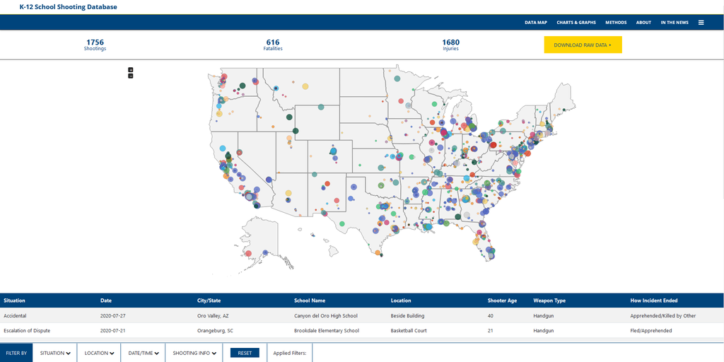

Source: Center for Homeland Defense and Security (https://www.chds.us/ssdb/data-map/)

So we got discussing that given the mountain of events what tends to be the most impactful factor in the size of casualties and the interplay between the individual factors.

My initial hypothesis is that age and access to weaponry will be the most impactful factor in predicting casualties. The implication of which being that gun control is an important factor in reducing casualties. I preface this analysis by saying that this is a charged and multifaceted issue so I by no means want to claim causality - lets leave that one to the academics and the incredibly impartial lobbying groups 😉

## Lets look at the data

The schema for this data is based off 4 tables:

1. shooter: Incident ID number and details about the shooter. Multiple rows have the same incident ID number if there were multiple shooters.
2. incident: Incident ID number and the details of what, where, and when the shooting happened.
3. victim: Incident ID number and details about the victim. Multiple rows have the same incident ID number if there were multiple victims.
4. weapon: Incident ID number and details about the weapon used (including weapons that were possessed by the shooter during the incident but were not fired). Multiple rows have the same incident ID number if there were multiple weapons used.

```r
head(shooter)
```

```
## # A tibble: 6 x 12
##   incidentid   age   gender race    schoolaffiliation shooteroutcome shooterdied
##   <chr>        <chr> <chr>  <chr>   <chr>             <chr>          <chr>
## 1 19700105DCH~ 15    Male   <NA>    Student           Unknown        No
## 2 19700105DCS~ <NA>  Male   <NA>    Student           Surrendered    No
## 3 19700105DCU~ <NA>  Male   <NA>    Student           Fled/Escaped   No
## 4 19700206OHJ~ 18    Male   Hispan~ Student           Unknown        No
## 5 19700323CAD~ 16    Male   Hispan~ Student           Surrendered    No
## 6 19700323CAD~ 44    Male   Hispan~ Police Officer/S~ Surrendered    No
## # ... with 5 more variables: injury <chr>, chargesfiled <chr>, verdict <chr>,
## #   minorchargedadult <chr>, criminalhistory <chr>
```

```r
head(incident)
```

```
## # A tibble: 6 x 30
##   Incident_ID Sources Number_News Media_Attention Reliability Date       Quarter
##   <chr>       <chr>   <chr>       <chr>                 <dbl> <date>     <chr>
## 1 20200727AZ~ "https~ 3           Local                     4 2020-07-27 Summer
## 2 20200721SC~ "https~ 2           Local                     3 2020-07-21 Summer
## 3 20200714MI~ "https~ 1           Local                     3 2020-07-14 Summer
## 4 20200704IN~ "https~ 2           Local                     4 2020-07-04 Summer
## 5 20200701IL~ "https~ 1           Local                     3 2020-07-01 Summer
## 6 20200627VA~ "https~ 2           Local                     4 2020-06-27 Summer
## # ... with 23 more variables: School <chr>, City <chr>, State <chr>,
## #   School_Level <chr>, Location <chr>, Location_Type <chr>,
## #   During_School <chr>, Time_Period <chr>, First_Shot <chr>, Summary <chr>,
## #   Narrative <chr>, Situation <chr>, Targets <chr>, Accomplice <chr>,
## #   Hostages <chr>, Barricade <chr>, Officer_Involved <chr>, Bullied <chr>,
## #   Domestic_Violence <chr>, Gang_Related <chr>, Preplanned <chr>,
## #   Shots_Fired <chr>, Active_Shooter_FBI <chr>
```

```r
head(victim)
```

```
## # A tibble: 6 x 6
##   incidentid    race  injury  gender schoolaffiliation age
##   <chr>         <chr> <chr>   <chr>  <chr>             <chr>
## 1 19700105DCHIW <NA>  Fatal   Male   Student           15
## 2 19700105DCSOW <NA>  Wounded Male   Student           Teen
## 3 19700105DCUNW <NA>  None    Male   Unknown           16
## 4 19700206OHJOC <NA>  Wounded Male   Student           18
## 5 19700323CADAL <NA>  Wounded Male   Security Guard    44
## 6 19700323CADAL <NA>  Wounded Male   Student           16
```

```r
head(weapon)
```

```
## # A tibble: 6 x 4
##   incidentid    weaponcaliber weapondetails weapontype
##   <chr>         <chr>         <chr>         <chr>
## 1 19700105DCHIW Unknown       <NA>          Handgun
## 2 19700105DCSOW .22 caliber   <NA>          Handgun
## 3 19700105DCUNW Unknown       <NA>          Handgun
## 4 19700206OHJOC Unknown       <NA>          Handgun
## 5 19700323CADAL Unknown       <NA>          Handgun
## 6 19700415ARPIP Unknown       <NA>          Multiple Handguns
```